{% raw %}

{% endraw %} {% raw %}

{% endraw %} {% raw %}

{% endraw %}

## Conv2d Pruning

{% raw %}

{% endraw %}

A `Conv2d` layer possess a 4d-tensor as weights. This means that there exist many ways of removing blocks from it.

### 0-D Blocks

In the case of convolution filters, removing 0-D elements is equivalent to removing individual weights.

- `weight` granularity

{% raw %}

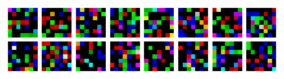

```python
get_pruned_conv(0)
```

{% endraw %}

### 1-D Blocks

1-D blocks of elements is equivalent to removing vectors from the convolution filters. There are several ways to chose the vectors, that will be represented below.

- `shared_weight`: this granularity is very particular as it removes individual weights from a filter, but with a pattern that is shared across all filters.

{% raw %}

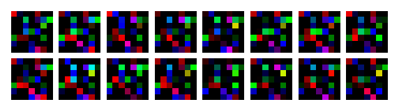

```python
get_pruned_conv(1)
```

{% endraw %}

- `channel`: remove vector of weights along the channel axis.

{% raw %}

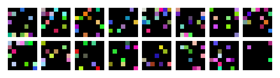

```python
get_pruned_conv(2)
```

{% endraw %}

- `column`: remove vector of weights along the height axis.

{% raw %}

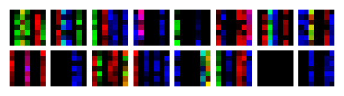

```python
get_pruned_conv(3)
```

{% endraw %}

- `row`: remove vector of weights along the width axis.

{% raw %}

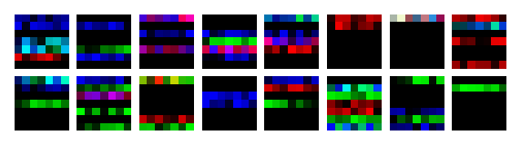

```python
get_pruned_conv(4)
```

{% endraw %}

### 2-D Blocks

- `shared_channel`: remove vector of weight along the channel axis, but with a pattern that is shared across all filters.

{% raw %}

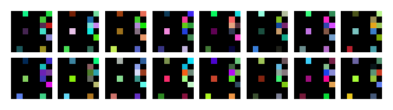

```python
get_pruned_conv((1,2))
```

{% endraw %}

- `shared_column`: remove vector of weight along the height axis, but with a pattern that is shared across all filters.

{% raw %}

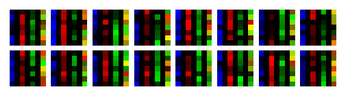

```python
get_pruned_conv((1,3))
```

{% endraw %}

- `shared_row`: remove vector of weight along the width axis, but with a pattern that is shared across all filters.

{% raw %}

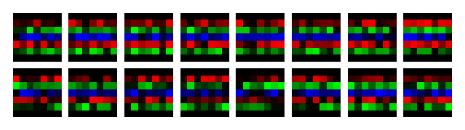

```python
get_pruned_conv((1,4))
```

{% endraw %}

- `vertical_slice`: remove vertical slices of weight along the height axis.

{% raw %}

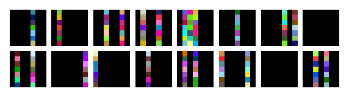

```python
get_pruned_conv((2,3))
```

{% endraw %}

{% raw %}

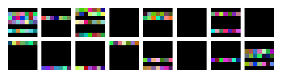

```python
get_pruned_conv((2,4))
```

{% endraw %}

- `kernel`: remove kernels of from the convolution filters.

{% raw %}

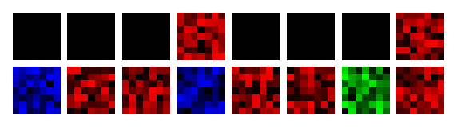

```python
get_pruned_conv((3,4))
```

{% endraw %}

### 3-D Blocks

- `shared_vertical_slice`: remove vertical slices of weight along the height axis, with a pattern that is shared across all filters.

{% raw %}

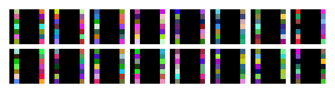

```python
get_pruned_conv((1,2,3))
```

{% endraw %}

- `shared_horizontal_slice`: remove horizontal slices of weight along the width axis, with a pattern that is shared across all filters.

{% raw %}

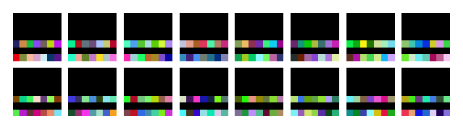

```python
get_pruned_conv((1,2,4))
```

{% endraw %}

- `shared_kernel`: remove kernels of weight from the convolution filters, with a pattern that is shared across all filters.

{% raw %}

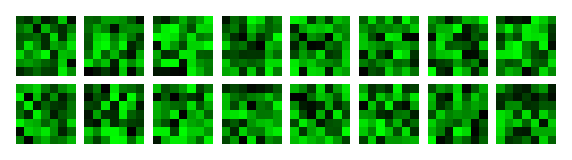

```python
get_pruned_conv((1,3,4))
```

{% endraw %}

- `filter`: remove entire filters.

{% raw %}

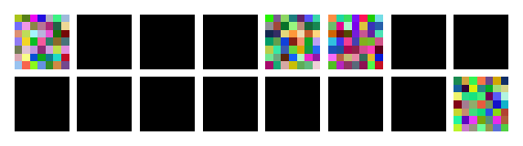

```python
get_pruned_conv((2,3,4))
```

{% endraw %}

## Linear Pruning

{% raw %}

{% endraw %}

### 0-D Blocks

As for the convolution filters, weights from a Linear layer can be removed independently.

- `weight`: remove individual weights.

{% raw %}

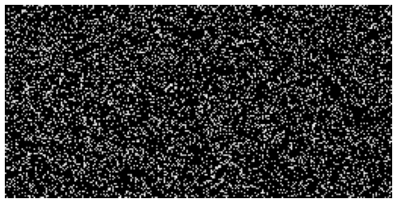

```python
get_pruned_linear(0)
```

{% endraw %}

### 1-D Blocks

- `column`: remove column of weight, which corresponds to removing input neurons.

{% raw %}

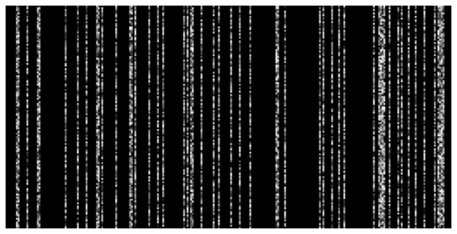

```python
get_pruned_linear(1)
```

{% endraw %}

- `row`: remove rows of weight, which corresponds to removing output neurons.

{% raw %}

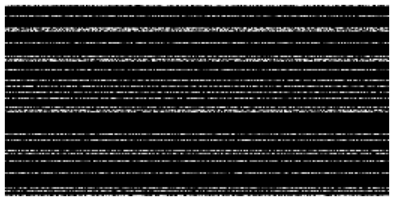

```python
get_pruned_linear(2)
```

{% endraw %}

## Transformer Pruning

{% include note.html content='This is an experimental part of the library' %}

{% raw %}

{% endraw %} {% raw %}

`available_granularities`[[source]](https://github.com/nathanhubens/fasterai/tree/master/fasterai/sparse/granularity.py#L22)

> `available_granularities`()

{% endraw %} {% raw %}

{% endraw %}